# Coursera Milestone Report

Raghavendra Dabral

11 November 2022

## Synopsis

This is the Milestone Report for Coursera JHU Data Science Specialization

The objective of this report is to develop an understanding of the various statistical properties of the [HC Corpora Dataset](https://d396qusza40orc.cloudfront.net/dsscapstone/dataset/Coursera-SwiftKey.zip) that can be used later to build the prediction model for the final data product - the Shiny application. Using EDA, this report describes the major features of the training data and then summarizes all plans for creating the final model.

The model will be trained from the following three sources of text data:

1. Blogs
2. News
3. Twitter

This project will only focus on the English corpora.

## Environment Setup

```r
library(knitr)
rm(list = ls(all.names = TRUE))
```

## Load the Data

Download, unzip and load the training data.

```r
trainURL <- "https://d396qusza40orc.cloudfront.net/dsscapstone/dataset/Coursera-SwiftKey.zip"
trainDataFile <- "data/Coursera-SwiftKey.zip"

if (!file.exists('data')) {
    dir.create('data')
}

if (!file.exists("data/final/en_US")) {
    tempFile <- tempfile()
    download.file(trainURL, tempFile)
    unzip(tempFile, exdir = "data")
    unlink(tempFile)
}

# blogs
blogsFileName <- "data/final/en_US/en_US.blogs.txt"
con <- file(blogsFileName, open = "r")
blogs <- readLines(con, encoding = "UTF-8", skipNul = TRUE)
close(con)

# news
newsFileName <- "data/final/en_US/en_US.news.txt"
con <- file(newsFileName, open = "r")
news <- readLines(con, encoding = "UTF-8", skipNul = TRUE)
close(con)

# twitter
twitterFileName <- "data/final/en_US/en_US.twitter.txt"
con <- file(twitterFileName, open = "r")
twitter <- readLines(con, encoding = "UTF-8", skipNul = TRUE)
close(con)

rm(con)
```

## Summary of the Data

A brief description of the three text corpora is given here, including the file sizes, number of lines, characters, and words for each source file. This is done before creating the unified document corpus and cleaning the data. Basic statistics on the number of words per line are also provided (min, mean, and max).

### Initial Data Summary

| File | FileSize | Lines | Characters | Words | WPL.Min | WPL.Mean | WPL.Max |
| --- | --- | --- | --- | --- | --- | --- | --- |
| en_US.blogs.txt | 200 MB | 899288 | 206824505 | 37570839 | 0 | 42 | 6726 |
| en_US.news.txt | 196 MB | 77259 | 15639408 | 2651432 | 1 | 35 | 1123 |
| en_US.twitter.txt | 159 MB | 2360148 | 162096241 | 30451170 | 1 | 13 | 47 |

A preliminary analysis of the data reveals that, on average, each text corpus has a low word count per line. In general, blogs have more words per line than news, which is followed by twitter, which has the fewest words per line. Given that a tweet may only include a fixed amount of characters, the lower number of words per line for the Twitter data was to be expected. Research indicates that barely 1% of tweets exceed the 280-character limit, and only 12% of tweets are longer than 140 characters, despite Twitter’s increase in character limit from 140 to 280 in 2017. Perhaps consumers were simply conditioned to the 140-character limit after so many years.

The size of the text files is another crucial finding from this preliminary analysis. A sample size of 1% will be obtained from all three data sets to reduce processing time, and the data will then be integrated into a single document corpus for further analyses later in this report.

### Histogram to show words in each line

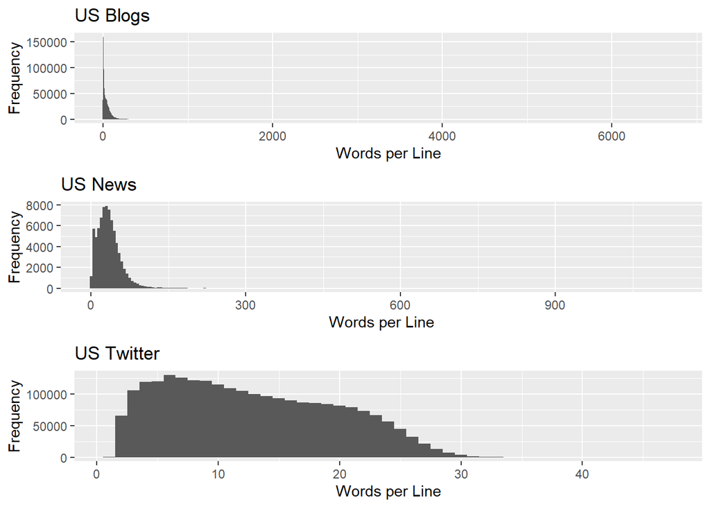

The histogram plots above also indicate the comparatively low word count in the three source files that were tracked before in this section. This finding appears to confirm a general tendency for brief and to the point communications, which could prove helpful later on in the project.

## Preparing the Data

The next step is to compile the sampled data set into a corpus. The transformation will be applied to each document using a custom function called `buildCorpus`.

The corpus will then be saved to disc in two different formats: as a text file and as a serialized R object in RDS format. Finally, the corpus’s first 10 documents (lines) will be shown.

First 10 Documents

| splash fresh lime juice |
| --- |
| found hidden just behind screens |
| well cant take just piece specifically inspirational piece |
| los angeles clippers s grizzlies pm tntlac |
| can may ventured boldly |
| aside hit house |
| long starting first current fulltime social work position one clients experienced something eerily similar something identify connected decision enter field potential comparisons seemed endless father… |
| today looked like raining day sad pumped spring already tired coats time put fur wool away year |
| sartorially uniqloj far cry another collection launched week burberrys winter storm w lean mean much magnetic hinges upon pieces complex texture craftsmanship plush quilted biker jackets thoroughly mo… |
| pull bowls oven remove foil add cheese egg mixture stir combine place mixture well cover foil place back oven minutes remove foil bake minutes serve |

## Exploratory Data Analysis

To achieve the main objective of this study, exploratory data analysis will be carried out. The most commonly used words, tokenizing, and n-gram creation are a few of the strategies that will be used to establish an understanding of the training data.

### Word Frequencies

To show unusual word frequencies, a bar chart and word cloud will be created.

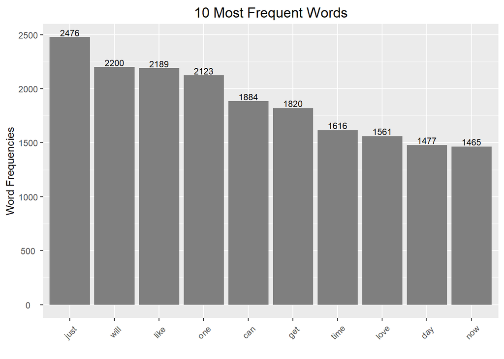

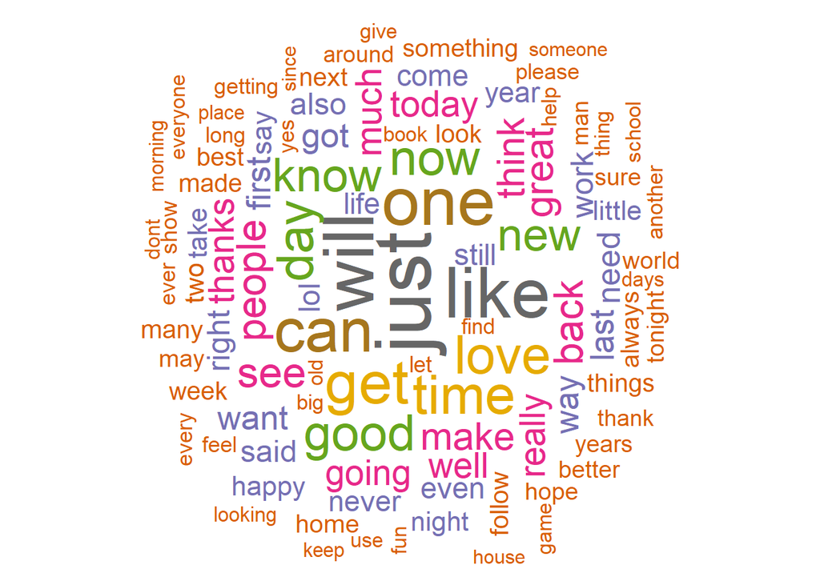

### Tokenizing and N-Gram Generation

Unigrams, bigrams and trigrams will all be supported by the predictive model I intend to create for the Shiny application. I’ll build functions to tokenize the example data and create matrices of uniqrams, bigrams, and trigrams in this part using the `RWeka` package.

#### Unigrams

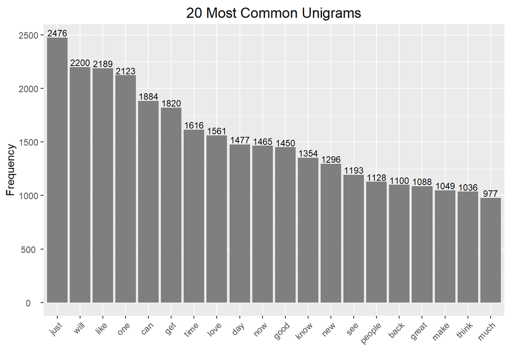

#### Bigrams

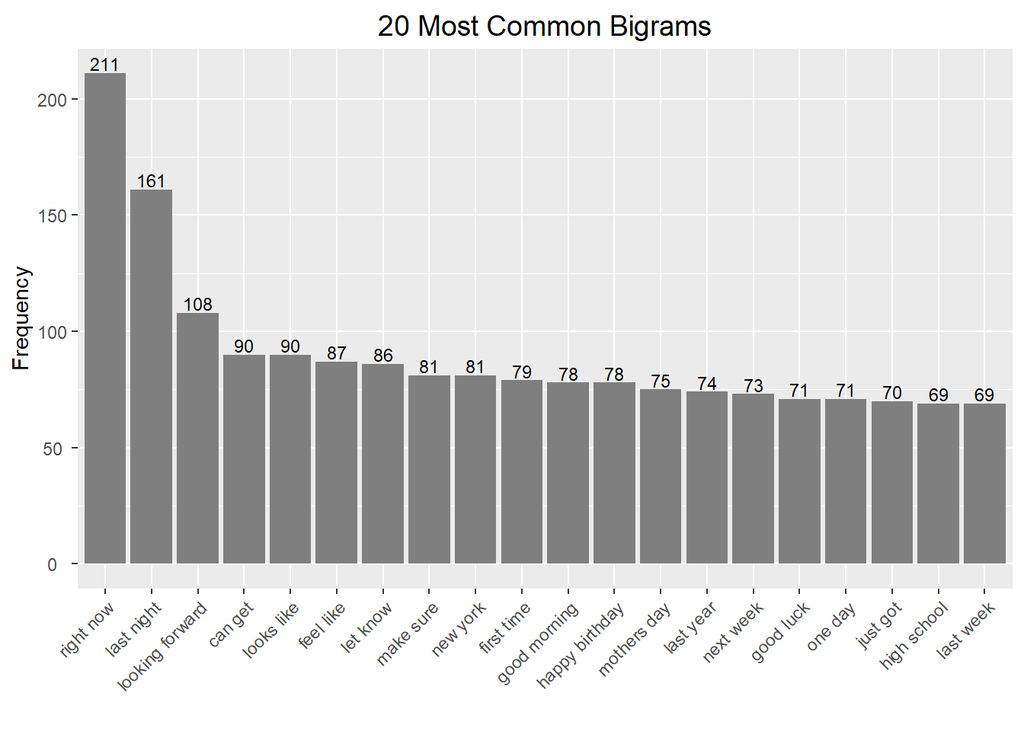

#### Trigrams

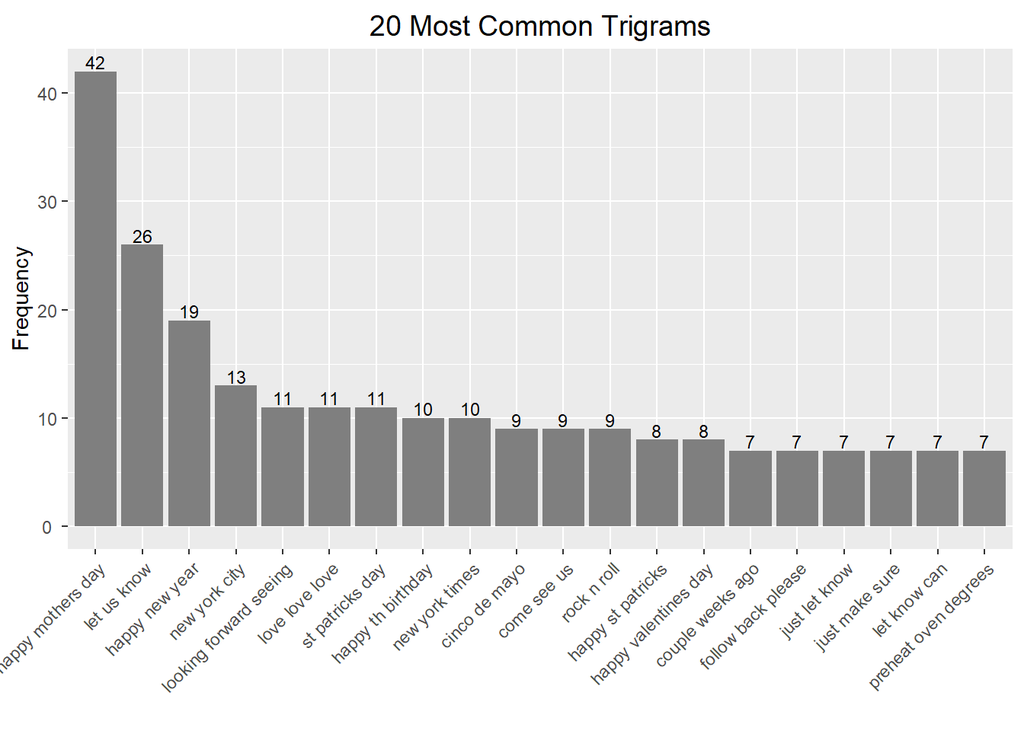

## Further steps in the future

The Shiny app should accept a phrase (multiple words) as input and output the next word prediction. For this, an n-gram model with a word frequency lookup similar to that carried out in the exploratory data analysis part of this report will be used to create the prediction algorithm. Based on the data acquired during the exploratory investigation, a strategy will be developed. For instance, the frequency of each of its phrases fell as n for each n-gram rose. Therefore, one approach may be to build the model to look for the unigram that would result from the entered text first. Find the most prevalent bigram model after a full phrase is typed, followed by a space, and so forth.